# Projekt

Miłosz Alfler

2022-01-31

# Analiza ocen serialu “Przyjaciele”

Celem projektu jest przedstawienie ocen sezonów, odcinków i aktorów wystawionych przez uzytkowników portalu filmweb.

## Sezony

Na wstępie widzimy zestawienie wszystkich sezonów serialu wraz z ich ocenami, latami emisji i liczbą głosów. W tabeli zaznaczony jest sezon 5, który ma najwyższą ocenę.

Ranking sezonów serialu Przyjaciele

| Sezon | Ocena | Lata emisji | Liczba głosów |
| --- | --- | --- | --- |
| Sezon 1 | 8,7 | 1994 - 1995 | 1031 |
| Sezon 2 | 9,0 | 1995 - 1996 | 898 |
| Sezon 3 | 8,9 | 1996 - 1997 | 799 |
| Sezon 4 | 9,1 | 1997 - 1998 | 770 |
| Sezon 5 | 9,2 | 1998 - 1999 | 808 |
| Sezon 6 | 9,0 | 1999 - 2000 | 712 |
| Sezon 7 | 9,0 | 2000 - 2001 | 660 |
| Sezon 8 | 8,9 | 2001 - 2002 | 646 |
| Sezon 9 | 8,8 | 2002 - 2003 | 647 |
| Sezon 10 | 9,0 | 2003 - 2004 | 676 |

Niżej widzimy to zestawienie w postaci wykresu kolumnowego.

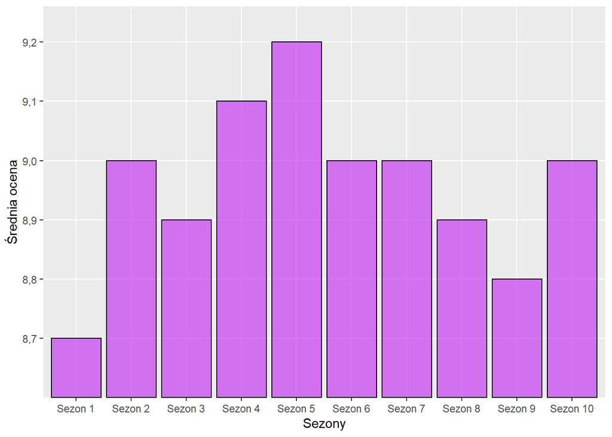

## TOP 50 odcinków

TOP 50 odcinków

| Nazwa odcinka | Ocena odcinka | Data emisji | Liczba głosów | Numer sezonu | Numer odcinka |
| --- | --- | --- | --- | --- | --- |
| Ten, w którym wszyscy się dowiadują | 9,4 | 11.02.1999 | 1487 | 5 | 14 |
| Ten ostatni: część 2 | 9,4 | 30.12.2004 | 1121 | 10 | 19 |
| Ten z oświadczynami: część 2 | 9,2 | 27.05.2003 | 1228 | 6 | 25 |
| Ten ostatni: część 1 | 9,2 | 30.12.2004 | 1036 | 10 | 18 |
| Ten w Vegas: część 2 | 9,1 | 20.05.1999 | 1241 | 5 | 24 |
| Ten ze ślubem Moniki i Chandlera: część 2 | 9,1 | 17.05.2001 | 1153 | 7 | 24 |
| Ten z filmem ze studniówki | 9,0 | 23.10.1996 | 1427 | 2 | 14 |
| Ten z embrionami | 9,0 | 15.01.1998 | 1289 | 4 | 12 |
| Ten z weselem Rossa: część 2 | 9,0 | 07.05.1998 | 1284 | 4 | 24 |
| Ten z plotką | 9,0 | 22.11.2001 | 1175 | 8 | 9 |
| Ten z czerwonym swetrem | 9,0 | 04.10.2001 | 1128 | 8 | 2 |
| Ten, w którym Rachel rodzi dziecko: część 2 | 9,0 | 16.05.2002 | 1090 | 8 | 24 |
| Ten z przyjęciem pożegnalnym Rachel | 9,0 | 23.12.2004 | 1070 | 10 | 17 |
| Ten, w którym Ross się dowiaduje | 8,9 | 14.10.1996 | 1430 | 2 | 7 |
| Ten z migawką z przeszłości | 8,9 | 31.10.1996 | 1350 | 3 | 6 |
| Ten z całowaniem | 8,9 | 01.10.1998 | 1270 | 5 | 2 |
| Ten ze wspomnieniami ze Świąt Dziękczynienia | 8,9 | 19.11.1998 | 1251 | 5 | 8 |
| Ten z Chandlerem w skrzyni | 8,9 | 20.11.1997 | 1239 | 4 | 8 |
| Ten z postanowieniami | 8,9 | 07.01.1999 | 1209 | 5 | 11 |
| Ten, w którym Ross się naćpał | 8,9 | 01.04.2003 | 1177 | 6 | 9 |
| Ten, w którym Paul jest prawdziwym facetem | 8,9 | 15.05.2003 | 1156 | 6 | 22 |
| Ten z oświadczynami: część 1 | 8,9 | 22.05.2003 | 1154 | 6 | 24 |
| Ten z partnerską drzemką | 8,9 | 09.11.2000 | 1130 | 7 | 6 |
| Ten z kasetą | 8,9 | 18.10.2001 | 1123 | 8 | 4 |
| Ten, w którym Joey umawia się z Rachel | 8,9 | 10.01.2002 | 1111 | 8 | 12 |
| Ten, w którym Rachel rodzi dziecko: część 1 | 8,9 | 16.05.2002 | 1082 | 8 | 23 |
| Ten ze ślubem Phoebe | 8,9 | 25.11.2004 | 1048 | 10 | 13 |
| The One In Barbados (2) | 8,9 | 15.05.2003 | 1044 | 9 | 24 |
| Ten, w którym Ross i Rachel... No wiecie | 8,8 | 24.10.1996 | 1379 | 2 | 15 |
| Ten z dwoma przyjęciami | 8,8 | 06.11.1996 | 1337 | 2 | 22 |
| Ten z meduzą | 8,8 | 25.09.1997 | 1286 | 4 | 1 |
| Ten z kurczakiem. I kaczką | 8,8 | 17.04.1997 | 1281 | 3 | 21 |
| Ten na plaży | 8,8 | 15.05.1997 | 1268 | 3 | 25 |
| Ten z kanapką Rossa | 8,8 | 10.12.1998 | 1218 | 5 | 9 |
| Ten z sukniami ślubnymi | 8,8 | 16.04.1998 | 1205 | 4 | 20 |
| Ten w Vegas: część 1 | 8,8 | 20.05.1999 | 1199 | 5 | 23 |
| Ten, w którym ktoś musi się wycofać | 8,8 | 29.10.1998 | 1185 | 5 | 5 |
| Ten z pierścionkiem | 8,8 | 20.05.2003 | 1128 | 6 | 23 |
| Ten ze ślubem Moniki i Chandlera: część 1 | 8,8 | 17.05.2001 | 1121 | 10 | 4 |
| Ten, w którym Rachel mówi... | 8,8 | 11.10.2001 | 1116 | 8 | 3 |
| Ten, w którym Ross ma się dobrze | 8,8 | 09.09.2004 | 1101 | 10 | 3 |
| Ten z prawdą o Londynie | 8,8 | 22.02.2001 | 1098 | 7 | 16 |
| Ten, w którym Ross śpiewa nieodpowiednią piosenkę | 8,8 | 14.11.2002 | 1090 | 9 | 7 |
| Ten z opalenizną Rossa | 8,8 | 16.09.2004 | 1081 | 10 | 12 |
| Ten, w którym striptizer płacze | 8,8 | 18.11.2004 | 1073 | 7 | 23 |
| Ten, w którym Joey mówi po francusku | 8,8 | 02.12.2004 | 1065 | 10 | 14 |

Poniżej ta sama tabela przedstawiona w formie wykresu kolumnowego. Widzimy jak często dany sezon występował w top 50.

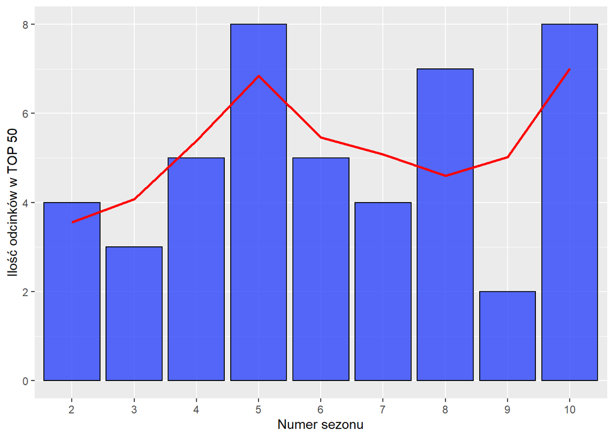

## Postacie

Imie aktora

Imie postaci

Ocena

Liczba głosów

Zdjęcie

Matthew Perry

Chandler Bing

9,5

8 657 ocen

Matt LeBlanc

Joey Tribbiani

9,4

7 697 ocen

Lisa Kudrow

Phoebe Buffay

9,3

7 570 ocen

Jennifer Aniston

Rachel Green

9,2

8 917 ocen

David Schwimmer

Dr Ross Geller / Russ

9,1

6 980 ocen

Courteney Cox

Monica Geller

9,1

7 004 oceny

## Zestawienie z innymi serialami

Ostatnim już elementem jest zestawienie ocen poszczególnych sezonów z innymi serialami. Do porównania posłużyły seriale: “Bojack Horseman”, “Gra o tron” i “Breaking Bad”.

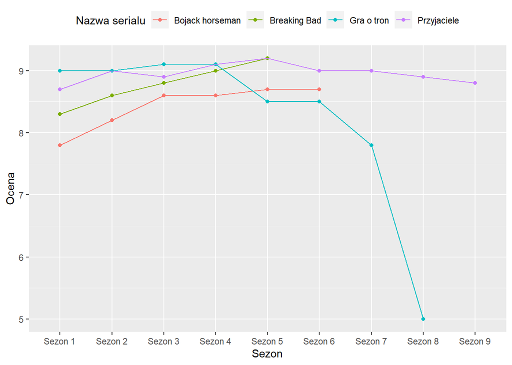

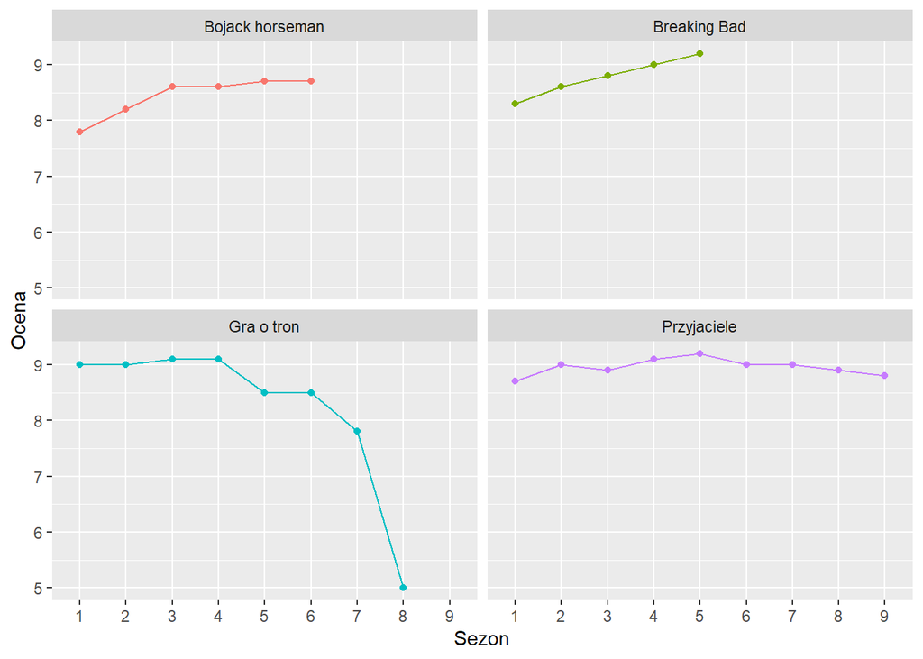

## Źródła

[Ranking sezonów](https://www.filmweb.pl/serial/Przyjaciele-1994-33993/seasons/ranking)

[TOP 50 odcinków](https://www.filmweb.pl/serial/Przyjaciele-1994-33993/episode/ranking)

[Ranking postaci i aktorów](https://www.filmweb.pl/serial/Przyjaciele-1994-33993)

[Bojack Horseman](https://www.filmweb.pl/serial/BoJack+Horseman-2014-718443/seasons/ranking)

[Gra o tron](https://www.filmweb.pl/serial/Gra+o+tron-2011-476848/seasons/ranking)

[Breaking bad](https://www.filmweb.pl/serial/Breaking+Bad-2008-430668/seasons/ranking)